# Explore data for machine learning wave model

**Author:** Leo Peach

**Date:** 22-12-2018

## Initial data requirements

The initial investigation will follow a similar method to that used in James et al 2017. Initially we will focus on developing the necessary data for the MLP model (Mult-layer perceptron).

**Data:**

Wave Buoy from Queensland Government and Hindcast from CSIRO

- Hindcast model Hs at an offshore location which also suitable to for a forecast model
- Hindcast model Hs at or near the wave buoy locations
- Historical Wave Buoy data

### Get the Hindcast Data

The hindcast data is in daily grid files, to get data for one location we are going to access each file and grab the data we want.

```python
import netCDF4
import numpy as np
import pandas as pd
import datetime as dt
import matplotlib.pyplot as plt
```

```python
#wave buoy info
brisbane = {'name': 'Brisbane, Australia', 'lat': -27.54722, 'lon': 153.8667}
gold_coast = {'name': 'Gold Coast, Australia', 'lat': -27.9646, 'lon': 153.4404} # location in metadata incorrect
```

```python
def extract_hindcast(file, wb_info):
    '''Parsed a hindcast netCDF file
    Returns a dataframe with the relevant data for a location'''

    fh = netCDF4.Dataset(file,'r')
    lons = fh.variables['longitude'][:]
    lats = fh.variables['latitude'][:]
    hs = fh.variables['hs'][:]
    t02 = fh.variables['t02'][:]
    u10 = fh.variables['U10'][:]
    v10 = fh.variables['V10'][:]
    time = fh.variables['time'][:]
    pkdir = fh.variables['dp'][:]
    pkfreq = fh.variables['fp'][:]
    fh.close()

    latidx = np.abs(lats - wb_info['lat']).argmin()
    lonidx = np.abs(lons - wb_info['lon']).argmin()

    hs = pd.Series(hs[:,latidx, lonidx])
    t02 = pd.Series(t02[:,latidx, lonidx])
    u10 = pd.Series(u10[:,latidx, lonidx])
    v10 = pd.Series(v10[:, latidx, lonidx])
    pkfreq = pd.Series(pkfreq[:,latidx, lonidx])
    pkdir = pd.Series(pkdir[:,latidx, lonidx])

    tstr = file[-13:-3]

    start = tstr + " 00:00"
    end = tstr + " 23:00"
    dateidx = pd.date_range(start,end , freq='H')
    data = pd.concat([hs, t02,u10, v10, pkfreq, pkdir], axis = 1)
    data.index = dateidx
    data.columns = ['hs','t02','u10', 'v10','pkfreq','pkdir']

    return data
```

```python
import os
hindcast_directory = 'D:/Masters/data/hindcast/'
gc_hc_list = []
errs = 0
for file in os.listdir(hindcast_directory):
    if file.endswith('.nc'):
        try:
            gc_hc_list.append(extract_hindcast(os.path.join(hindcast_directory+file), gold_coast))
        except:
            errs +=1
            continue

gc_hc = pd.concat(gc_hc_list)
```

Save data at this point to ensure we don't need to run this again for gold wave bouy location

```python
gc_hc.to_csv('gold_coast_hindcast.csv')
```

Now that that the data is in CSV format grab it anduse it instead of re-processing

```python
gc_hc = pd.read_csv('D:/Masters/python/machine_learning/gold_coast_hindcast.csv')
```

```python
gc_hc.index = pd.to_datetime(gc_hc['Unnamed: 0'])
```

```python
gc_hc.head()
```

| Unnamed: 0 | Unnamed: 0 | hs | t02 | u10 | v10 | pkfreq | pkdir |
| --- | --- | --- | --- | --- | --- | --- | --- |
| 1979-01-01 00:00:00 | 1979-01-01 00:00:00 | 0.000 | 1.98 | -3.8 | 3.5 | NaN | NaN |
| 1979-01-01 01:00:00 | 1979-01-01 01:00:00 | 0.122 | 1.46 | -3.8 | 3.5 | NaN | NaN |
| 1979-01-01 02:00:00 | 1979-01-01 02:00:00 | 0.238 | 1.51 | -3.8 | 3.3 | NaN | NaN |
| 1979-01-01 03:00:00 | 1979-01-01 03:00:00 | 0.268 | 1.88 | -4.2 | 3.1 | 0.423 | 117.0 |
| 1979-01-01 04:00:00 | 1979-01-01 04:00:00 | 0.280 | 2.10 | -4.9 | 2.9 | 0.391 | 116.0 |

### Select a suitable offshore location

first location select offshore of the wave buoy in approx -500m depth.

```python
loc1_gc = {'name': 'Location1, Australia', 'lat': -27.9646, 'lon': 154.061}
```

```python
import os
hindcast_directory = 'D:/Masters/data/hindcast/'
lc_hc1_list = []
errs = 0
for file in os.listdir(hindcast_directory):
    if file.endswith('.nc'):
        try:
            lc_hc1_list.append(extract_hindcast(os.path.join(hindcast_directory+file), gold_coast))
        except:
            errs +=1
            continue
print(errs)
lc1_hc = pd.concat(lc_hc1_list)
```

also save this as a csv

```python
lc1_hc.to_csv('loc1_hindcast.csv')
```

now that we have this saved as a csv, use this instead of retrieving the data again

```python
lc1_hc = pd.read_csv('D:/Masters/python/machine_learning/loc1_hindcast.csv')
```

```python
lc1_hc.index = pd.to_datetime(gc_hc['Unnamed: 0'])
```

```python
lc1_hc.head()
```

| Unnamed: 0 | Unnamed: 0 | hs | t02 | u10 | v10 | pkfreq | pkdir |
| --- | --- | --- | --- | --- | --- | --- | --- |
| 1979-01-01 00:00:00 | 1979-01-01 00:00:00 | 0.000 | 1.98 | -3.8 | 3.5 | NaN | NaN |
| 1979-01-01 01:00:00 | 1979-01-01 01:00:00 | 0.122 | 1.46 | -3.8 | 3.5 | NaN | NaN |
| 1979-01-01 02:00:00 | 1979-01-01 02:00:00 | 0.238 | 1.51 | -3.8 | 3.3 | NaN | NaN |
| 1979-01-01 03:00:00 | 1979-01-01 03:00:00 | 0.268 | 1.88 | -4.2 | 3.1 | 0.423 | 117.0 |
| 1979-01-01 04:00:00 | 1979-01-01 04:00:00 | 0.280 | 2.10 | -4.9 | 2.9 | 0.391 | 116.0 |

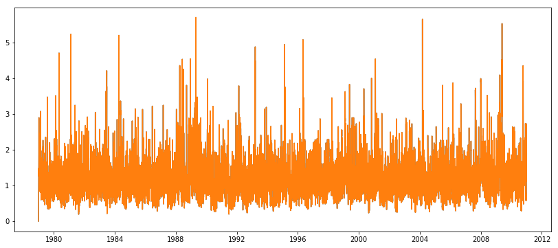

```python
fig, ax = plt.subplots(figsize = (14, 6))
ax.plot(lc1_hc.index, lc1_hc.hs)
ax.plot(gc_hc.index, gc_hc.hs)
plt.show()
```

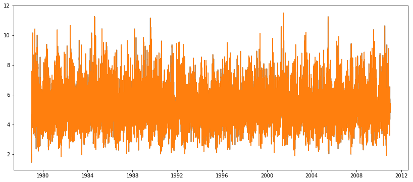

```python
fig, ax = plt.subplots(figsize = (14, 6))
ax.plot(lc1_hc.index, lc1_hc.t02)
ax.plot(gc_hc.index, gc_hc.t02)
plt.show()
```

However we will need to look at other parts of the data to see how well the model has performed against the wave buoy data generally, are there trends that need to be accounted for within the data?

Plot the data in bokeh so that it is easier to interogate

```python
from bokeh.io import output_notebook, show, push_notebook
from bokeh.plotting import figure
from bokeh.models import ColumnDataSource, Span
from bokeh.models.tools import HoverTool
output_notebook()
```

```python
p = figure(x_axis_type="datetime", plot_height = 500, plot_width = 800, title='hindcast data comparison' )
plotf =p.line(x = gc_hc.index,y = gc_hc.hs, color = 'blue',legend='Wave Buoy Site')
p.add_tools(HoverTool(renderers=[plotf], tooltips=[("Hs","@y")],mode='vline'))
plota = p.line(lc1_hc.index, lc1_hc.hs, color = 'green',legend='Offshore')
p.add_tools(HoverTool(renderers=[plota], tooltips=[("Hs","@y")],mode='vline'))


p.yaxis.axis_label = "Signifcant Wave Height (m)"

p.legend.location = "top_left"
p.legend.click_policy="hide"
show(p)
```

[output not shown]

## Comparison with WB data

A comparison of the WB data we have and the hindcast dataset for the same location

```python
wb_data_filename = r'D:/Masters/python/machine_learning/gold_coast_wb_cleaned.csv'
```

```python
wb_data = pd.read_csv(wb_data_filename, index_col = 0, parse_dates = True)
```

```python
wb_data = wb_data.sort_index()
```

```python
print(wb_data.index[0], wb_data.index[-1])
```

```
1987-02-21 08:55:00 2018-10-31 23:30:00
```

```python
hindcast_filename = r'D:/Masters/python/machine_learning/gold_coast_hindcast.csv'
```

```python
hindcast_data = pd.read_csv(hindcast_filename, index_col = 0, parse_dates = True)
```

```python
hindcast_data = hindcast_data.loc['1987-02-21 09:00':]
```

```python
hindcast_data.index[-1]
```

```
Timestamp('2010-12-31 23:00:00')
```

```python
wb_data = wb_data.loc[:'2010-12-31']
```

```python
wb_data = wb_data[['Hs','Tz', 'Tp','pkdir']]
```

```python
hindcast_data = hindcast_data[['hs','t02','pkfreq','pkdir']]
```

Convert peak frequency to peak period

```python
hindcast_data['pkfreq'] = 1/ hindcast_data['pkfreq']
```

```python
hindcast_data = hindcast_data.rename(index=str, columns={"hs": "Hs", "t02": "Tz", "pkfreq":"Tp"})
```

```python
wb_data.head()
```

| Date/Time | Hs | Tz | Tp | pkdir |
| --- | --- | --- | --- | --- |
| 1987-02-21 08:55:00 | 1.00 | 5.59 | 7.05 | NaN |
| 1987-02-21 14:56:00 | 1.05 | 4.45 | 7.19 | NaN |
| 1987-02-21 20:53:00 | 1.08 | 5.14 | 7.24 | NaN |
| 1987-02-22 02:51:00 | 0.99 | 5.25 | 7.25 | NaN |
| 1987-02-22 08:55:00 | 0.83 | 5.51 | 7.39 | NaN |

```python
hindcast_data.head()
```

|  | Hs | Tz | Tp | pkdir |
| --- | --- | --- | --- | --- |
| 1987-02-21 09:00:00 | 1.134 | 4.36 | 7.092199 | 83.0 |
| 1987-02-21 10:00:00 | 1.118 | 4.39 | 7.042254 | 83.0 |
| 1987-02-21 11:00:00 | 1.100 | 4.43 | 7.042254 | 83.0 |
| 1987-02-21 12:00:00 | 1.078 | 4.48 | 6.993007 | 84.0 |
| 1987-02-21 13:00:00 | 1.066 | 4.42 | 6.993007 | 84.0 |

Now we need to interpolate the data to the same time format

```python
wb_data_interp = wb_data.resample('1h').bfill(limit=1).interpolate()
```

```python
hindcast_data.index = pd.to_datetime(hindcast_data.index)
```

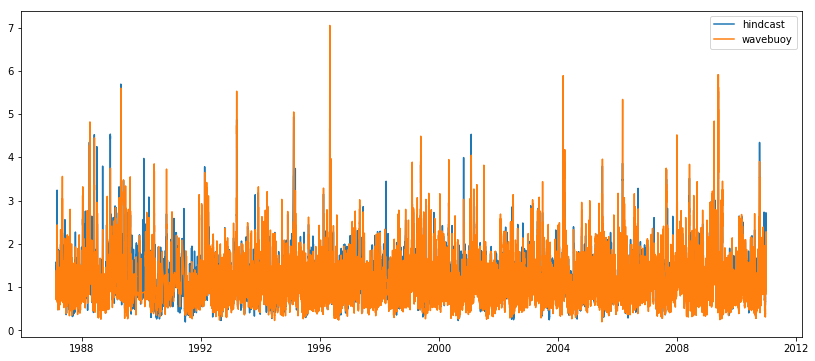

```python
fig, ax = plt.subplots(figsize = (14, 6))
ax.plot(hindcast_data.index, hindcast_data.Hs, label = 'hindcast')
ax.plot(wb_data_interp[1:].index, wb_data_interp[1:].Hs, label = 'wavebuoy')
plt.legend()
plt.show()
```

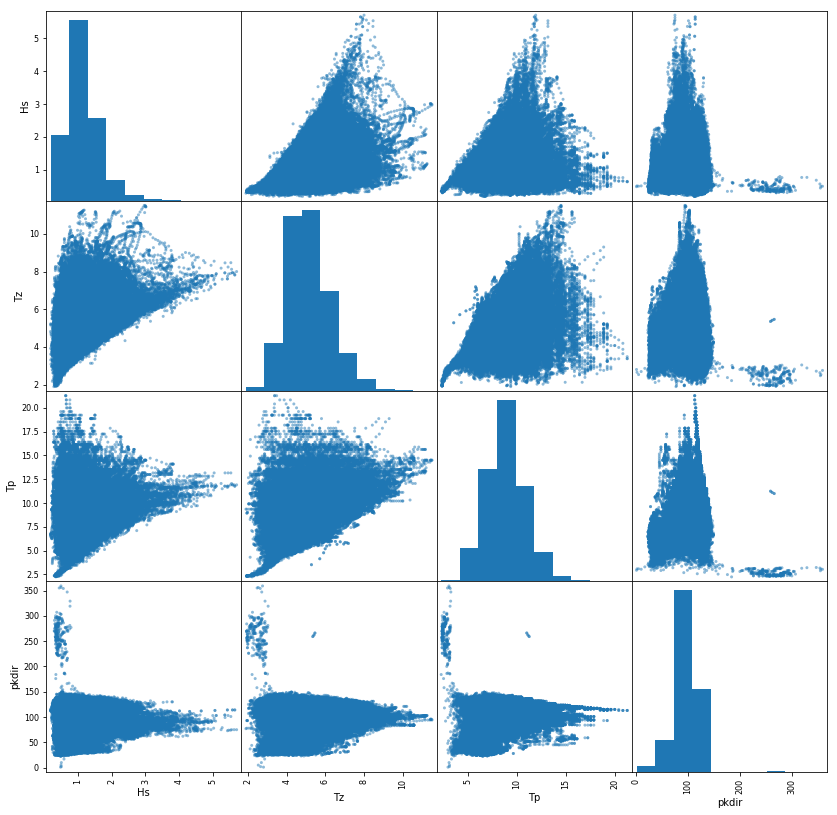

```python
from pandas import plotting

hindcast_scatter = plotting.scatter_matrix(hindcast_data, alpha = 0.5, figsize = (14, 14))
```

create a combined dataframe for comparison

```python
wb_data_interp['source'] = 'wave buoy'
```

```python
hindcast_data['source'] = 'hindcast'
```

```python
combined = pd.concat([wb_data_interp,hindcast_data])
```

```python
import seaborn as sns
sns.set_style("white")
colours = ['windows blue', 'greyish']
```

```python
sns.palplot(sns.xkcd_palette(colours))
```

[output not shown]

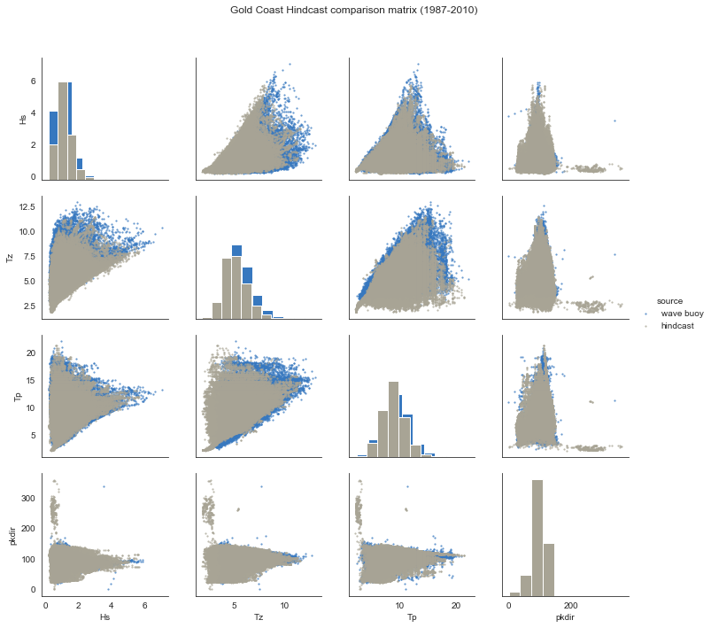

```python
pairplt = sns.pairplot(combined, hue="source", diag_kind = 'hist',plot_kws = {'alpha': 0.75, 's': 5, 'edgecolor': 'k',
                                                                             'linewidth' :0}, palette = sns.xkcd_palette(colours))
pairplt.fig.suptitle('Gold Coast Hindcast comparison matrix (1987-2010)')
pairplt.fig.subplots_adjust(top=.9)
plt.savefig('gold_coast_comparison_matrix.png')
```

## Comparitive Statistics

In order to measure the similarity between the Hindcast model and the recroded data over the period we will compare the overlapping datasets.

**Correlation**

```python
wb_data_interp.Hs.corr(hindcast_data.Hs)
```

```
0.8161723825035221
```

```python
wb_data_interp.Tz.corr(hindcast_data.Tz)
```

```
0.49410156204469424
```

```python
wb_data_interp.Tp.corr(hindcast_data.Tp)
```

```
0.4361751729667104
```

```python
wb_data_interp.pkdir.corr(hindcast_data.pkdir)
```

```
0.5340731576138681
```

Best value = 0.0

```python
from sklearn.metrics import mean_squared_error, mean_absolute_error, explained_variance_score
```

```python
mean_squared_error(wb_data_interp.loc[hindcast_data.index].Hs, hindcast_data.Hs)
```

```
0.09052734243585876
```

```python
mean_absolute_error(wb_data_interp.loc[hindcast_data.index].Hs, hindcast_data.Hs)
```

```
0.21260746103628508
```

```python
mean_squared_error(wb_data_interp.loc[hindcast_data.index].Tz, hindcast_data.Tz)
```

```
1.7732443762246959
```

```python
mean_absolute_error(wb_data_interp.loc[hindcast_data.index].Tz, hindcast_data.Tz)
```

```
0.9505038817364095
```

```python
mean_squared_error(wb_data_interp.loc[hindcast_data.index].Tp, hindcast_data.Tp)
```

```
5.75690646503502
```

```python
mean_absolute_error(wb_data_interp.loc[hindcast_data.index].Tp, hindcast_data.Tp)
```

```
1.5567921869687742
```

**Variance**

Best Value 1.0

```python
explained_variance_score(wb_data_interp.loc[hindcast_data.index].Hs, hindcast_data.Hs)
```

```
0.6357589432227202
```

```python
explained_variance_score(wb_data_interp.loc[hindcast_data.index].Tz, hindcast_data.Tz)
```

```
0.02472878300670589
```

```python
explained_variance_score(wb_data_interp.loc[hindcast_data.index].Tp, hindcast_data.Tp)
```

```
0.0166738219398046
```